# Week 2 laboratory

Return distributions across asset classes

Author

MTH1097 Financial and Actuarial Data Analysis

## Purpose

**How well does a normal/lognormal model describe different asset classes, and which financial conclusions depend on it?**

This is a two-hour formative laboratory. Nothing is submitted for marks. Complete the tasks in this worksheet and retain the rendered HTML as a record of your work.

You will estimate models, diagnose their departures from the data, examine correctly calibrated tests, and explore a jump scenario. The four series are the same investments as in Week 1:

| Series | Exposure | Investor currency |
| --- | --- | --- |
| Equities | VWRL.AS, global equities | EUR |
| Bonds | IEGA.AS, euro government bonds | EUR |
| Gold | PHAU.L, physical gold converted from USD | EUR |
| Portfolio | 60% equities, 30% bonds, 10% gold | EUR |

The supplied returns use the lecture’s frozen 2020–2025 data. They are **nominal total returns**, without safe-account discounting or transaction costs. The portfolio resets its weights at each common observation. This differs from the excess-return calculations and transaction-cost exercise in Week 1.

## Working with AI

Continue the Week 1 workflow:

1. State the financial question and predict one feature of the answer.
2. Request one small piece of R code.
3. Read and explain it before running it.
4. Check definitions, units and numerical identities.
5. Interpret the result in your own words.

Use the supplied R reference for function names and assumptions. Ask AI to simplify any code you cannot explain. Never accept a model merely because a function runs or a p-value is large.

## Timing and outputs

| Minutes | Task | Keep in your worksheet |
| --- | --- | --- |
| 0–10 | Audit the verified returns | Audit table and identity checks |
| 10–30 | Fit the normal/lognormal benchmark | Parameter and one-day outcome table |
| 30–55 | Compare graphical evidence | Histograms and QQ plots for all four series |
| 55–80 | Compare daily and monthly normality tests | Test tables, sample sizes and interpretations |
| 80–95 | Investigate KS calibration | Simulation comparison and an explanation of refitting |
| 95–110 | Explore a jump scenario | Model comparison and a change of one parameter |
| 110–120 | Write the conclusion | Six to eight evidence-based sentences |

Extensions are optional. Complete the cross-asset comparison before attempting them.

## Setup

Extract the whole student ZIP and open its folder. Run this chunk first.

```r
library(dplyr)
library(tidyr)
library(readr)
library(ggplot2)
library(scales)

find_lab_dir <- function(start = ".") {
  start <- normalizePath(start, winslash = "/", mustWork = FALSE)
  current <- start
  while (TRUE) {
    candidates <- c(
      current,
      file.path(current, "week02_lab"),
      file.path(current, "week02", "lab"),
      file.path(current, ".."),
      file.path(current, "..", "week02_lab")
    )
    for (p in candidates) {
      if (dir.exists(p) && file.exists(file.path(p, "week02_lab_helpers.R"))) {
        return(normalizePath(p, winslash = "/"))
      }
    }
    parent <- dirname(current)
    if (parent == current) break
    current <- parent
  }
  return(NA_character_)
}

lab_dir <- find_lab_dir()
stopifnot(!is.na(lab_dir))
source(file.path(lab_dir, "week02_lab_helpers.R"))

data_candidates <- c(file.path(lab_dir, "data"),
                     file.path(lab_dir, "../data/frozen"),
                     file.path(lab_dir, "..", "data"))
data_dir <- data_candidates[
  file.exists(file.path(data_candidates, "returns_daily_eur.csv"))
][1]
stopifnot(!is.na(data_dir))

daily <- read_csv(file.path(data_dir, "returns_daily_eur.csv"),
                  show_col_types = FALSE)
monthly <- read_csv(file.path(data_dir, "returns_monthly_eur.csv"),
                    show_col_types = FALSE)
asset_order <- c("Equities", "Bonds", "Gold", "Portfolio")
daily <- daily |> mutate(asset = factor(asset, levels = asset_order))
monthly <- monthly |> mutate(asset = factor(asset, levels = asset_order))

theme_set(theme_minimal(base_size = 12))
options(dplyr.summarise.inform = FALSE)
```

`week02_r_reference.html` explains the supplied functions. `DATA_DICTIONARY.md` explains the columns. Return values are decimals: `0.01` means 1%.

**Note**

The blank worksheet renders successfully. Add your code in the task chunks, then render again to include your results. The supplied HTML is a reading copy of the blank worksheet.

## Task 1: Audit and reconnect to Week 1

**Before running:** which identity should connect the portfolio’s simple return to its three components?

1. Report the number of observations and the first and last interval dates for each series, separately for daily and monthly data.
2. Check for duplicate asset-date pairs, missing return values and nonpositive gross returns. Do not drop rows silently.
3. Verify, to within $10^{-12}$, $G=\exp(r)$ and $R=\exp(r)-1$.
4. Put the four daily simple returns side by side by date. Verify

$$R_{P,t}=0.6R_{E,t}+0.3R_{B,t}+0.1R_{G,t},
\qquad r_{P,t}=\log(1+R_{P,t}).$$

```r
# Produce the daily/monthly audit table and perform the checks.

# 1) Audit table: counts and interval endpoints by asset/frequency.
asset_audit <- function(df, freq) {
  summary_tbl <- df |>
    group_by(asset) |>
    summarise(
      n = n(),
      first_date = min(date),
      last_date = max(date),
      missing_gross_return = sum(is.na(gross_return)),
      missing_simple_return = sum(is.na(simple_return)),
      missing_log_return = sum(is.na(log_return)),
      nonpositive_gross_return = sum(gross_return <= 0, na.rm = TRUE),
      .groups = "drop"
    ) |>
    mutate(frequency = freq, .before = asset)

  duplicate_pairs <- df |>
    count(date, asset, name = "rows_per_pair") |>
    filter(rows_per_pair > 1L)

  if (nrow(duplicate_pairs) > 0L) {
    warning(
      paste0(
        "Duplicate asset-date pairs found in the ", freq,
        " data; rows were retained instead of being dropped silently."
      ),
      call. = FALSE
    )
    print(duplicate_pairs)
  } else {
    message("No duplicate asset-date pairs in the ", freq, " data.")
  }

  missing_rows <- df |>
    filter(
      is.na(gross_return) |
        is.na(simple_return) |
        is.na(log_return)
    )

  if (nrow(missing_rows) > 0L) {
    warning(
      paste0(
        "Missing return values found in the ", freq,
        " data; rows were retained instead of being dropped silently."
      ),
      call. = FALSE
    )
    print(missing_rows)
  } else {
    message("No missing return values in the ", freq, " data.")
  }

  nonpositive_rows <- df |>
    filter(gross_return <= 0)

  if (nrow(nonpositive_rows) > 0L) {
    warning(
      paste0(
        "Nonpositive gross returns found in the ", freq,
        " data; rows were retained instead of being dropped silently."
      ),
      call. = FALSE
    )
    print(nonpositive_rows)
  } else {
    message("No nonpositive gross returns in the ", freq, " data.")
  }

  list(summary = summary_tbl,
       duplicates = duplicate_pairs,
       missing_rows = missing_rows,
       nonpositive_rows = nonpositive_rows)
}

# Run the audit for both frequencies.
daily_audit <- asset_audit(daily, "daily")
monthly_audit <- asset_audit(monthly, "monthly")

audit_table <- bind_rows(daily_audit$summary, monthly_audit$summary) |>
  select(
    frequency, asset, n, first_date, last_date,
    missing_gross_return, missing_simple_return, missing_log_return,
    nonpositive_gross_return
  )

audit_table
```

```
# A tibble: 8 × 9
  frequency asset         n first_date last_date  missing_gross_return
  <chr>     <fct>     <int> <date>     <date>                    <int>
1 daily     Equities   1510 2020-01-03 2025-12-31                    0
2 daily     Bonds      1510 2020-01-03 2025-12-31                    0
3 daily     Gold       1510 2020-01-03 2025-12-31                    0
4 daily     Portfolio  1510 2020-01-03 2025-12-31                    0
5 monthly   Equities     71 2020-02-28 2025-12-31                    0
6 monthly   Bonds        71 2020-02-28 2025-12-31                    0
7 monthly   Gold         71 2020-02-28 2025-12-31                    0
8 monthly   Portfolio    71 2020-02-28 2025-12-31                    0
# ℹ 3 more variables: missing_simple_return <int>, missing_log_return <int>,
#   nonpositive_gross_return <int>
```

```r
# 2) Check the exponential identities for each row.
identity_check <- daily |>
  mutate(
    gross_identity_error = gross_return - exp(log_return),
    simple_identity_error = simple_return - (exp(log_return) - 1)
  )

max_gross_error <- max(abs(identity_check$gross_identity_error), na.rm = TRUE)
max_simple_error <- max(abs(identity_check$simple_identity_error), na.rm = TRUE)

c(
  `max |G - exp(r)|` = max_gross_error,
  `max |R - (exp(r) - 1)|` = max_simple_error
)
```

```
      max |G - exp(r)| max |R - (exp(r) - 1)|
          2.220446e-16           1.162265e-16
```

```r
stopifnot(max_gross_error <= 1e-12,
          max_simple_error <= 1e-12)

# 3) Check the portfolio identity using the four daily simple returns side by side.
portfolio_check <- daily |>
  select(date, asset, simple_return, log_return) |>
  pivot_wider(
    names_from = asset,
    values_from = c(simple_return, log_return),
    names_glue = "{asset}_{.value}"
  ) |>
  mutate(
    weighted_sum = 0.6 * Equities_simple_return +
      0.3 * Bonds_simple_return + 0.1 * Gold_simple_return,
    portfolio_identity_error = Portfolio_simple_return - weighted_sum,
    log_return_check = Portfolio_log_return - log(1 + Portfolio_simple_return)
  )

portfolio_check <- portfolio_check |>
  select(
    date,
    Equities_simple_return,
    Bonds_simple_return,
    Gold_simple_return,
    Portfolio_simple_return,
    weighted_sum,
    portfolio_identity_error,
    log_return_check
  )

portfolio_check |>
  filter(abs(portfolio_identity_error) > 1e-12) |>
  head()
```

```
# A tibble: 0 × 8
# ℹ 8 variables: date <date>, Equities_simple_return <dbl>,
#   Bonds_simple_return <dbl>, Gold_simple_return <dbl>,
#   Portfolio_simple_return <dbl>, weighted_sum <dbl>,
#   portfolio_identity_error <dbl>, log_return_check <dbl>
```

```r
max_portfolio_error <- max(abs(portfolio_check$portfolio_identity_error), na.rm = TRUE)
max_log_error <- max(abs(portfolio_check$log_return_check), na.rm = TRUE)

c(
  `max |R_P - (0.6R_E + 0.3R_B + 0.1R_G)|` = max_portfolio_error,
  `max |r_P - log(1 + R_P)|` = max_log_error
)
```

```
max |R_P - (0.6R_E + 0.3R_B + 0.1R_G)|               max |r_P - log(1 + R_P)|
                          2.081668e-17                           1.131907e-16
```

```r
stopifnot(max_portfolio_error <= 1e-12,
          max_log_error <= 1e-12)
```

**TipA possible AI prompt**

Using the existing daily and monthly data frames, write a small audit grouped by asset. Count observations and duplicate asset-date pairs, check the three return columns for missing values, and check the two exponential identities. Explain each check. Do not remove observations.

**Checkpoint:** 1,510 daily return intervals and 71 monthly return intervals per series. All four series use the same interval endpoints within each frequency.

**Why must portfolio simple returns be weighted before taking logs? Click after writing your answer.**

A weighted sum of simple returns follows from the self-financing wealth calculation with starting weights. The log is nonlinear, so averaging component log returns generally gives a different portfolio return.

**Interval convention.** “Daily” means one common trading-observation step. Weekends and exchange holidays can make its calendar length exceed one day. Monthly data use non-overlapping end-of-month wealth ratios, starting with February 2020. The first incomplete month is excluded.

## Task 2: Fit a benchmark and calculate investment outcomes

For each daily series, estimate the normal log-return parameters using

$$\widehat m=\bar r,\qquad
\widehat s=\sqrt{\frac{1}{n-1}\sum_{i=1}^n(r_i-\bar r)^2}.$$

**Predict first:** will the asset with the largest daily standard deviation also have the largest fitted one-day VaR?

For initial wealth $V=\text{EUR }100{,}000$ and $\alpha=99\%$, calculate:

$$E[R]=e^{\widehat m+\widehat s^2/2}-1,\quad
\operatorname{median}(R)=e^{\widehat m}-1,\quad
P(R<0)=\Phi(-\widehat m/\widehat s),$$

$$L=-VR,\qquad
\operatorname{VaR}_{.99}(L)
=V\left[1-\exp\{\widehat m+\widehat s\,\Phi^{-1}(.01)\}\right].$$

These are **one-day model outcomes**, meaning one common observation step. Use daily estimates directly; no annualisation is needed. The lecture’s numerical VaR example was one year, so its amounts should not match this table.

1. Build one row per series with $n$, $\widehat m$, $\widehat s$, fitted mean and median simple returns, loss probability and VaR.
2. Use `normal_outcomes()` to check your direct calculations for at least one series.
3. Verify that fitted mean simple return is at least fitted median simple return.
4. Compare the observed simple returns with the fitted lower 1% quantile. Report the fraction falling below it.

```r
# Estimate the four models and calculate one-day outcomes.
# Label percentages, EUR amounts, horizon and confidence level.

# 1) Fit each asset's daily log-return model.
daily_fit <- daily |>
  group_by(asset) |>
  summarise(
    n = n(),
    m = mean(log_return),
    s = sd(log_return),
    .groups = "drop"
  ) |>
  mutate(
    mean_simple = expm1(m + s^2 / 2),
    median_simple = expm1(m),
    loss_probability = pnorm(0, mean = m, sd = s),
    lower_log_quantile = qnorm(0.01, mean = m, sd = s),
    VaR_eur = 100000 * (-expm1(lower_log_quantile)),
    fraction_below_1pct = vapply(asset, function(a) {
      x <- daily$log_return[daily$asset == a]
      q <- qnorm(0.01, mean = mean(x), sd = sd(x))
      mean(daily$simple_return[daily$asset == a] < expm1(q))
    }, numeric(1)),
    horizon = "1 common trading step",
    wealth_eur = 100000,
    confidence_level = "99%",
    currency = "EUR"
  )

# 2) Check the direct calculations against the provided helper for one series.
equities_fit <- daily |>
  filter(asset == "Equities")

equities_direct <- daily_fit |>
  filter(asset == "Equities") |>
  transmute(
    mean_simple,
    median_simple,
    loss_probability,
    VaR_eur = VaR_eur
  )

equities_helper <- normal_outcomes(
  m = mean(equities_fit$log_return),
  s = sd(equities_fit$log_return),
  wealth = 100000,
  alpha = .99
)

comparison_equities <- bind_cols(equities_direct, equities_helper)
comparison_equities
```

```
# A tibble: 1 × 9
  mean_simple...1 median_simple...2 loss_probability...3 VaR_eur...4
            <dbl>             <dbl>                <dbl>       <dbl>
1        0.000471          0.000416                0.484       2365.
# ℹ 5 more variables: mean_simple...5 <dbl>, median_simple...6 <dbl>,
#   loss_probability...7 <dbl>, lower_log_quantile <dbl>, VaR_eur...9 <dbl>
```

```r
# 3) Verify the fitted mean simple return is at least the fitted median.
stopifnot(all(daily_fit$mean_simple >= daily_fit$median_simple))

# 4) Report the fraction of observed simple returns below the fitted 1% lower quantile.
daily_fit |>
  select(
    asset, n, m, s, mean_simple, median_simple,
    loss_probability, VaR_eur, fraction_below_1pct,
    horizon, wealth_eur, confidence_level, currency
  )
```

```
# A tibble: 4 × 13
  asset         n          m       s mean_simple median_simple loss_probability
  <fct>     <int>      <dbl>   <dbl>       <dbl>         <dbl>            <dbl>
1 Equities   1510  0.000416  0.0105    0.000471      0.000416             0.484
2 Bonds      1510 -0.0000663 0.00397  -0.0000584    -0.0000663            0.507
3 Gold       1510  0.000638  0.0103    0.000692      0.000639             0.475
4 Portfolio  1510  0.000312  0.00665   0.000334      0.000312             0.481
# ℹ 6 more variables: VaR_eur <dbl>, fraction_below_1pct <dbl>, horizon <chr>,
#   wealth_eur <dbl>, confidence_level <chr>, currency <chr>
```

**Your interpretation:** which comparison agrees with your prediction? Explain the difference between volatility and the probability of any loss.

**Does a fitted 99% VaR mean that larger losses are impossible?**

No. Under the continuous fitted model, 1% of losses exceed this threshold. Historical exceedances here use the same sample as the fit, so they are an in-sample diagnostic, not a forecast validation.

## Task 3: Diagnose the distribution graphically

**Predict first:** which series do you expect to have the most pronounced departures after dividing by its own standard deviation?

1. Make four histograms of daily log returns and overlay the corresponding fitted normal densities. Use density, not frequency, on the vertical axis. Label axis ranges if they differ across assets.
2. Standardise each series separately: $z_{i}=(r_i-\widehat m)/\widehat s$.
3. Make four QQ plots with theoretical standard-normal quantiles horizontally, ordered standardised observations vertically, and the line $y=x$.
4. Calculate sample skewness and excess kurtosis using `return_moments()`.
5. For each asset, write one sentence about the centre, symmetry and tails. Compare the portfolio’s volatility and excess kurtosis with equities.

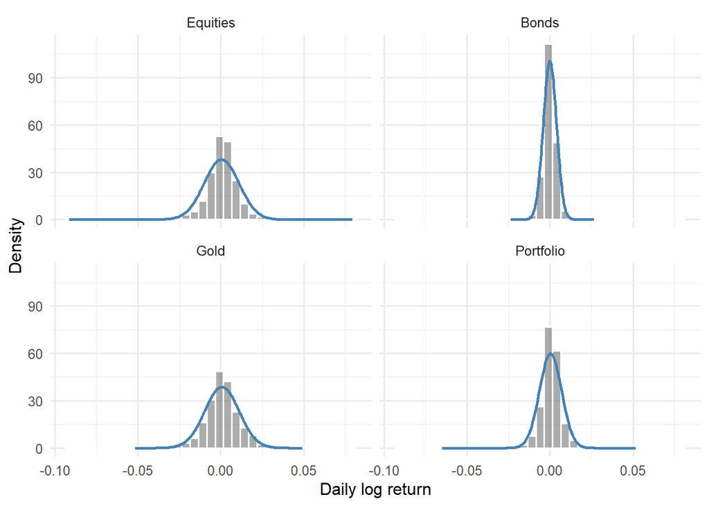

```r
# Histograms with fitted normal density overlays.
daily_density <- daily |>
  group_by(asset) |>
  group_modify(~ {
    x <- .x$log_return
    fit <- normal_fit(x)
    tibble(
      log_return = seq(min(x), max(x), length.out = 200L),
      density = dnorm(log_return, mean = fit["m"], sd = fit["s"])
    )
  }) |>
  ungroup()

ggplot(daily, aes(x = log_return)) +
  geom_histogram(
    aes(y = after_stat(density)),
    bins = 35,
    colour = "white",
    alpha = 0.5
  ) +
  geom_line(
    data = daily_density,
    aes(x = log_return, y = density),
    linewidth = 1,
    colour = "steelblue"
  ) +
  facet_wrap(~ asset, ncol = 2) +
  labs(x = "Daily log return", y = "Density")
```

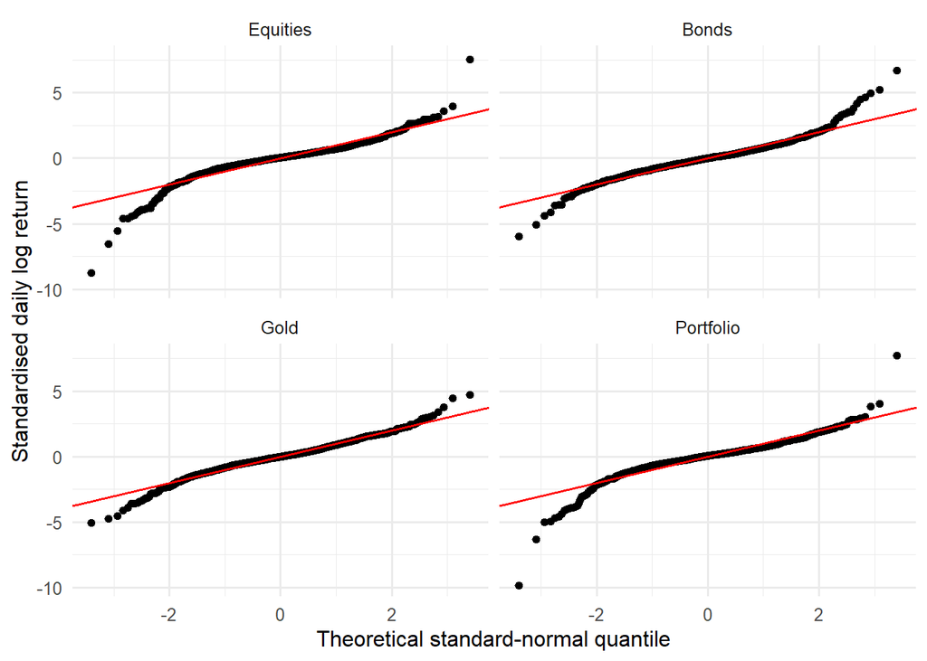

```r
# Standardised QQ plots, moment table, and interpretation.
daily_z <- daily |>
  group_by(asset) |>
  mutate(z = (log_return - mean(log_return)) / sd(log_return)) |>
  ungroup()

ggplot(daily_z, aes(sample = z)) +
  stat_qq(distribution = qnorm) +
  geom_abline(intercept = 0, slope = 1, colour = "red") +
  facet_wrap(~ asset, ncol = 2) +
  labs(
    x = "Theoretical standard-normal quantile",
    y = "Standardised daily log return"
  )
```

```r
daily_moments <- daily |>
  group_by(asset) |>
  group_modify(~ {
    x <- .x$log_return
    moments <- return_moments(x)
    tibble(
      skewness = unname(moments["skewness"]),
      excess_kurtosis = unname(moments["excess_kurtosis"]),
      JB = unname(moments["JB"]),
      JB_p = unname(moments["JB_p"])
    )
  }) |>
  ungroup()

daily_moments
```

```
# A tibble: 4 × 5
  asset     skewness excess_kurtosis    JB     JB_p
  <fct>        <dbl>           <dbl> <dbl>    <dbl>
1 Equities    -0.987           10.0  6586. 0
2 Bonds        0.285            4.90 1533. 0
3 Gold        -0.282            2.41  386. 1.41e-84
4 Portfolio   -1.13            12.0  9406. 0
```

For each asset, the centre is close to zero, but the tails and symmetry differ. Equities and the portfolio are more negatively skewed and more leptokurtic than bonds and gold, so their left tails are much heavier than a normal reference. The portfolio has lower volatility than equities but still shows substantial tail excess, which is consistent with a concentrated risk profile driven by equity-market swings.

**TipPlotting check**

For faceted density overlays, create a separate grid and fitted density for each asset, then pass that data frame to `geom_line()`. A single ungrouped density curve would use the wrong parameters for some panels.

**What shape indicates more extreme observations than a normal reference?**

With theoretical quantiles on the horizontal axis, the left tail bends below the line and the right tail above it. Unequal departures can indicate asymmetry. Location and scale adjustments alone cannot remove this curvature.

**Keep your graphical diagnosis before moving on to p-values.**

## Task 4: Tests, asset classes and observation frequency

The reference hypothesis is that observations are IID normal with unknown mean and variance. The core tests are:

| Test | Discrepancy | Reference used here |
| --- | --- | --- |
| Shapiro–Wilk | Ordered sample values relative to normal order statistics | R’s normality-test implementation |
| Jarque–Bera | Skewness and kurtosis | Asymptotic chi-square with 2 degrees of freedom |
| Anderson–Darling | Weighted CDF differences, emphasising both tails | Normal simulations with mean and sample SD refitted |

Use the provided functions as follows. This is a function-use example; apply it to all four series.

```r
x <- daily$log_return[daily$asset == "Equities"]
daily_reference <- normal_mc_reference(n = length(x), B = 4999)
normal_tests(x, daily_reference)
```

Generate **one reference per sample size**. The same reference serves every asset at that frequency because fitted-normal statistics are invariant to location and scale. Do not reuse the daily reference for the monthly sample.

1. Produce daily and monthly tables of $n$, SW, JB and AD p-values for all four series.
2. Display very small p-values as `<0.0001`; use `format_p(p, B=4999)` for AD. An asterisk marks the smallest simulated value, $1/5000$, rather than a p-value of zero.
3. Add QQ plots of daily and monthly equities, standardised separately.
4. Compare the test results with your graphical diagnosis.
5. Explain any disagreement between tests, and what changed between frequencies.

```r
# Generate daily and monthly references, run the tests and construct tables.
daily_reference <- normal_mc_reference(n = length(daily$log_return[daily$asset == "Equities"]), B = 4999L)
monthly_reference <- normal_mc_reference(n = length(monthly$log_return[monthly$asset == "Equities"]), B = 4999L)

daily_tests <- daily |>
  group_by(asset) |>
  group_modify(~ as_tibble(normal_tests(.x$log_return, daily_reference))) |>
  ungroup()

monthly_tests <- monthly |>
  group_by(asset) |>
  group_modify(~ as_tibble(normal_tests(.x$log_return, monthly_reference))) |>
  ungroup()

daily_table <- daily_tests |>
  transmute(
    asset,
    n,
    SW = format_p(SW_p),
    JB = format_p(JB_p),
    AD = format_p(AD_p, B = 4999L)
  )

monthly_table <- monthly_tests |>
  transmute(
    asset,
    n,
    SW = format_p(SW_p),
    JB = format_p(JB_p),
    AD = format_p(AD_p, B = 4999L)
  )

list(
  daily = daily_table,
  monthly = monthly_table
)
```

```
$daily
# A tibble: 4 × 5
  asset         n SW      JB      AD
  <fct>     <int> <chr>   <chr>   <chr>
1 Equities   1510 <0.0001 <0.0001 0.0002*
2 Bonds      1510 <0.0001 <0.0001 0.0002*
3 Gold       1510 <0.0001 <0.0001 0.0002*
4 Portfolio  1510 <0.0001 <0.0001 0.0002*

$monthly
# A tibble: 4 × 5
  asset         n SW    JB    AD
  <fct>     <int> <chr> <chr> <chr>
1 Equities     71 0.119 0.038 0.183
2 Bonds        71 0.210 0.218 0.079
3 Gold         71 0.302 0.744 0.106
4 Portfolio    71 0.127 0.115 0.093
```

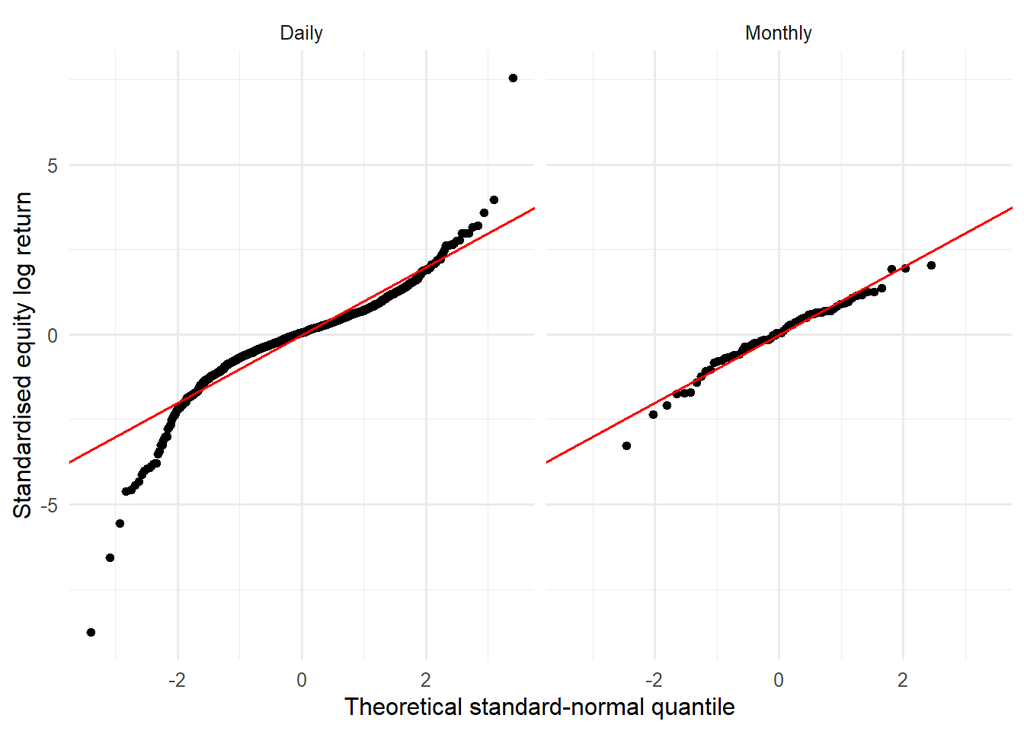

```r
# Daily/monthly equity QQ comparison and written interpretation.
equity_qq <- bind_rows(
  daily |>
    filter(asset == "Equities") |>
    mutate(
      frequency = "Daily",
      z = (log_return - mean(log_return)) / sd(log_return)
    ),
  monthly |>
    filter(asset == "Equities") |>
    mutate(
      frequency = "Monthly",
      z = (log_return - mean(log_return)) / sd(log_return)
    )
)

ggplot(equity_qq, aes(sample = z)) +
  stat_qq(distribution = qnorm) +
  geom_abline(intercept = 0, slope = 1, colour = "red") +
  facet_wrap(~ frequency, ncol = 2) +
  labs(
    x = "Theoretical standard-normal quantile",
    y = "Standardised equity log return"
  )
```

The daily equity QQ plot is visibly more curved than the monthly one, especially in the far left tail, which is consistent with the stronger daily departure from normality seen in the daily p-values. The monthly plot is less curved because aggregation reduces short-run volatility and the sample size is much smaller, so the monthly tests have lower power. This means the larger monthly p-values do not show that monthly returns are normal; they only indicate that the available monthly sample has less evidence against the fitted normal model.

**Write before opening the explanation:** “The monthly p-value is larger, therefore monthly returns are normal.” What is missing?

**Show the interpretation guide.**

Aggregation changes the return distribution, but it also reduces the sample from 1,510 to 71 observations. Tests may have less power. Non-rejection does not confirm normality. The reference also assumes independence and stable parameters, which these marginal plots and tests do not establish.

Do not choose the largest p-value as a model-selection score or count tests as independent votes. These are related descriptive investigations; a formal search for multiple discoveries would need an explicit multiplicity procedure.

## Task 5: Why KS needs refitting

The observed KS statistic compares the empirical CDF with a normal CDF fitted to the same sample. A fair reference must reproduce that fitting step.

Use **monthly equities** and the supplied experiment:

```r
x_month <- monthly$log_return[monthly$asset == "Equities"]
experiment <- ks_refit_experiment(x_month, B = 4999, seed = 209702)
experiment$p_values
```

Open `ks_refit_experiment()` in `week02_lab_helpers.R`. Identify the lines that:

1. fit the original mean and SD;
2. generate a new sample from those original parameters;
3. compare it with the original CDF;
4. refit mean and SD for the simulated comparison.

Then run the experiment and:

- plot the fixed-parameter and refitted reference statistics side by side, using common axes;
- mark the observed statistic on both panels;
- compare ordinary KS, fixed-parameter simulation and simulation with refitting;
- explain why the first two answer the wrong reference question here.

```r
# Run the experiment, plot its two reference distributions, and explain the p-values.
x_month <- monthly$log_return[monthly$asset == "Equities"]
experiment <- ks_refit_experiment(x_month, B = 4999, seed = 209702)
experiment$p_values
```

```
                                      calibration   p_value
1                Ordinary KS (inappropriate here) 0.7373576
2 Fixed-parameter simulation (inappropriate here) 0.7446000
3                       Simulation with refitting 0.3230000
```

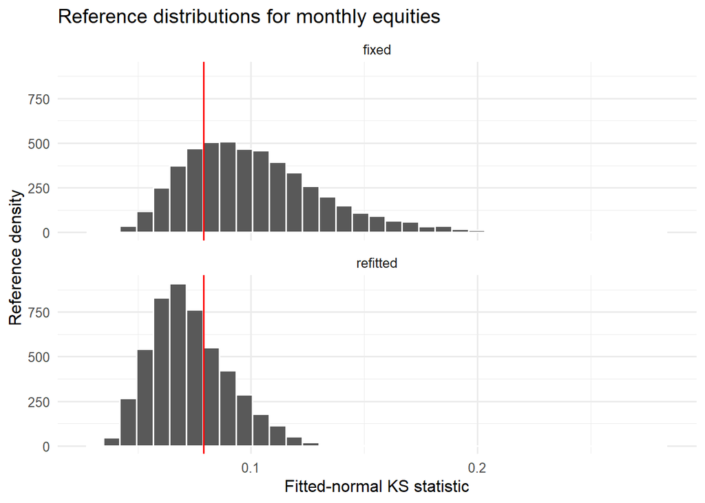

```r
experiment$draws |>
  pivot_longer(everything(), names_to = "reference", values_to = "KS") |>
  ggplot(aes(KS)) +
  geom_histogram(bins = 35, colour = "white") +
  geom_vline(xintercept = experiment$observed, colour = "red") +
  facet_wrap(~reference, ncol = 1, scales = "fixed") +
  labs(
    x = "Fitted-normal KS statistic",
    y = "Reference density",
    title = "Reference distributions for monthly equities"
  )
```

The ordinary KS p-value and the fixed-parameter simulation are both calibrated to the wrong question here. They compare the observed statistic with a distribution in which the fitted normal CDF is treated as fixed, whereas the observed KS statistic is computed against a normal CDF fitted to the same sample. In `ks_refit_experiment()`, the original mean and sample SD are fixed only to generate the bootstrap draws; each simulated sample then gets its own fitted mean and SD before `normal_discrepancy()` is evaluated. That second fit is the key step that the ordinary KS calibration and the fixed-parameter simulation omit, so their p-values answer a different reference problem and are not the correct fitted-normal reference for this data.

**Which parameters remain fixed, and which must change?**

The original estimates remain fixed as the generator of every bootstrap sample. Each new sample then gets its own estimates for calculating its discrepancy. Omitting that second fit compares the observed statistic with a different procedure, typically inflating the fitted-normal KS p-value.

The correctly refitted p-value need not equal the lecture’s simulated value exactly: the random seed is different. A useful scale for Monte Carlo error away from zero is $\sqrt{\widehat p(1-\widehat p)/B}$. The ordinary analytic KS value should agree for the identical sample.

## Task 6: A jump scenario with a financial mechanism

Use Merton’s model to investigate occasional discrete repricing:

$$r_h=ah+\sigma\sqrt h\,Z+\sum_{j=1}^{N_h}Y_j,\quad
N_h\sim\operatorname{Poisson}(\lambda h),\quad
Y_j\sim N(m_J,s_J^2).$$

Here $Z\sim N(0,1)$ and the components are independent. The supplied `jump_model()` sets

$$a=\mu-\sigma^2/2-\lambda\left(e^{m_J+s_J^2/2}-1\right),
\qquad E[e^{r_h}]=e^{\mu h}.$$

Start with the lecture’s **illustrative** annual parameters: $\mu=8\%$, $\sigma=14\%$, $\lambda=2$, $m_J=-4\%$, $s_J=6\%$, and horizon $h=1/252$ year.

```r
base_model <- jump_model()
r_jump <- simulate_jump_returns(100000, base_model, seed = 209706)
```

1. Simulate the base scenario. Check the sample mean of `exp(r_jump)` against `base_model$expected_gross`, allowing for Monte Carlo error.
2. Simulate a normal comparator using `base_model$log_mean` and `sqrt(base_model$log_variance)`. These match the log moments, not necessarily expected wealth.
3. For each model, report the **one-day 0.1% and 99.9% simple-return quantiles**, and corresponding wealth quantiles for EUR 100,000. Use analytical normal quantiles and `jump_quantile()` as numerical checks.
4. **Predict first:** what changes if expected jump frequency rises from 2 to 4 per year? Set `jump_model(lambda=4)` and rerun the comparison. Recompute the matched normal comparator for the new scenario.
5. Explain why the helper must also change the drift $a$.
6. Identify one feature in an observed asset’s QQ plot that makes jumps worth investigating. State one reason this exercise does not validate the model for that asset.

```r
# Base and higher-frequency scenarios, matched normal comparators, checks and quantiles.

# Base model from the lecture notes.
base_model <- jump_model(mu = .08, sigma = .14, lambda = 2,
                        jump_mean = -.04, jump_sd = .06, h = 1/252)
base_jump <- simulate_jump_returns(n = 100000, model = base_model, seed = 209706)
set.seed(209716)
base_normal <- rnorm(100000, mean = base_model$log_mean,
                    sd = sqrt(base_model$log_variance))

base_growth <- c(
  simulated = mean(exp(base_jump)),
  model = base_model$expected_gross,
  MC_standard_error = sd(exp(base_jump)) / sqrt(length(base_jump))
)
base_growth
```

```
        simulated             model MC_standard_error
     1.000324e+00      1.000318e+00      3.378689e-05
```

```r
# Matched normal comparison for the base model: same log moments, not same wealth.
base_normal_summary <- tibble(
  scenario = "base",
  probability = c(0.001, 0.999),
  jump_model_quantile = jump_quantile(c(0.001, 0.999), base_model),
  normal_model_quantile = qnorm(c(0.001, 0.999),
                                mean = base_model$log_mean,
                                sd = sqrt(base_model$log_variance)),
  simple_return_jump_model = expm1(jump_quantile(c(0.001, 0.999), base_model)),
  simple_return_normal = expm1(qnorm(c(0.001, 0.999),
                                     mean = base_model$log_mean,
                                     sd = sqrt(base_model$log_variance))),
  wealth_jump_model = 100000 * exp(jump_quantile(c(0.001, 0.999), base_model)),
  wealth_normal = 100000 * exp(qnorm(c(0.001, 0.999),
                                     mean = base_model$log_mean,
                                     sd = sqrt(base_model$log_variance)))
)
base_normal_summary
```

```
# A tibble: 2 × 8
  scenario probability jump_model_quantile normal_model_quantile
  <chr>          <dbl>               <dbl>                 <dbl>
1 base           0.001             -0.109                -0.0335
2 base           0.999              0.0335                0.0340
# ℹ 4 more variables: simple_return_jump_model <dbl>,
#   simple_return_normal <dbl>, wealth_jump_model <dbl>, wealth_normal <dbl>
```

```r
# Higher jump frequency: same mu and expected wealth growth, different jump intensity.
high_model <- jump_model(mu = .08, sigma = .14, lambda = 4,
                         jump_mean = -.04, jump_sd = .06, h = 1/252)
high_jump <- simulate_jump_returns(n = 100000, model = high_model, seed = 209707)
set.seed(209717)
high_normal <- rnorm(100000, mean = high_model$log_mean,
                     sd = sqrt(high_model$log_variance))

high_growth <- c(
  simulated = mean(exp(high_jump)),
  model = high_model$expected_gross,
  MC_standard_error = sd(exp(high_jump)) / sqrt(length(high_jump))
)
high_growth
```

```
        simulated             model MC_standard_error
     1.000260e+00      1.000318e+00      4.004498e-05
```

```r
high_normal_summary <- tibble(
  scenario = "higher_lambda",
  probability = c(0.001, 0.999),
  jump_model_quantile = jump_quantile(c(0.001, 0.999), high_model),
  normal_model_quantile = qnorm(c(0.001, 0.999),
                                mean = high_model$log_mean,
                                sd = sqrt(high_model$log_variance)),
  simple_return_jump_model = expm1(jump_quantile(c(0.001, 0.999), high_model)),
  simple_return_normal = expm1(qnorm(c(0.001, 0.999),
                                     mean = high_model$log_mean,
                                     sd = sqrt(high_model$log_variance))),
  wealth_jump_model = 100000 * exp(jump_quantile(c(0.001, 0.999), high_model)),
  wealth_normal = 100000 * exp(qnorm(c(0.001, 0.999),
                                     mean = high_model$log_mean,
                                     sd = sqrt(high_model$log_variance)))
)
high_normal_summary
```

```
# A tibble: 2 × 8
  scenario      probability jump_model_quantile normal_model_quantile
  <chr>               <dbl>               <dbl>                 <dbl>
1 higher_lambda       0.001             -0.132                -0.0389
2 higher_lambda       0.999              0.0534                0.0394
# ℹ 4 more variables: simple_return_jump_model <dbl>,
#   simple_return_normal <dbl>, wealth_jump_model <dbl>, wealth_normal <dbl>
```

```r
# Checks: mean wealth growth should remain close to the model value within Monte Carlo error.
stopifnot(abs(base_growth["simulated"] - base_growth["model"]) <= 5 * base_growth["MC_standard_error"])
stopifnot(abs(high_growth["simulated"] - high_growth["model"]) <= 5 * high_growth["MC_standard_error"])

# Direct tail checks against the simulated draw distribution.
base_simulated_quantiles <- quantile(base_jump, probs = c(0.001, 0.999), type = 7)
high_simulated_quantiles <- quantile(high_jump, probs = c(0.001, 0.999), type = 7)

list(
  base_jump_quantiles = base_simulated_quantiles,
  high_jump_quantiles = high_simulated_quantiles,
  base_model_tail = base_normal_summary,
  high_model_tail = high_normal_summary
)
```

```
$base_jump_quantiles
       0.1%       99.9%
-0.10851552  0.03331053

$high_jump_quantiles
       0.1%       99.9%
-0.13703476  0.05182261

$base_model_tail
# A tibble: 2 × 8
  scenario probability jump_model_quantile normal_model_quantile
  <chr>          <dbl>               <dbl>                 <dbl>
1 base           0.001             -0.109                -0.0335
2 base           0.999              0.0335                0.0340
# ℹ 4 more variables: simple_return_jump_model <dbl>,
#   simple_return_normal <dbl>, wealth_jump_model <dbl>, wealth_normal <dbl>

$high_model_tail
# A tibble: 2 × 8
  scenario      probability jump_model_quantile normal_model_quantile
  <chr>               <dbl>               <dbl>                 <dbl>
1 higher_lambda       0.001             -0.132                -0.0389
2 higher_lambda       0.999              0.0534                0.0394
# ℹ 4 more variables: simple_return_jump_model <dbl>,
#   simple_return_normal <dbl>, wealth_jump_model <dbl>, wealth_normal <dbl>
```

**What remains constant when lambda changes through jump_model()?**

The chosen expected wealth growth remains exp(mu*h), because the drift correction changes with jump frequency. The distribution and its log moments can still change. A normal comparator matching those log moments must be recalculated.

The extreme-quantile estimates use roughly 100 observations in each 0.1% tail when simulating 100,000 draws, so simulation uncertainty matters. Numerical model quantiles help separate simulation noise from model differences. Inspect both tails: a jump model need not give more extreme quantiles at every probability.

These are scenarios, not fitted models of the historical assets. Do not fit Student-t log returns: as discussed in the lecture, exponentiating them gives infinite expected wealth.

## Task 7: The comparative conclusion

Write six to eight sentences answering:

1. How does the portfolio’s daily volatility and one-day VaR compare with equities?
2. Does diversification also make the standardised tail shape more normal in this sample?
3. Which graphical departures agree with the tests?
4. What can and cannot be inferred from the monthly results?
5. What does the KS refitting experiment demonstrate?
6. What changes in the jump scenario, and what remains only a model assumption?

Support every numerical claim with your own checked results. Distinguish empirical observations, fitted-model calculations and illustrative simulations.

**Your conclusion:** 1. How does the portfolio’s daily volatility and one-day VaR compare with equities? - The portfolio is materially less volatile than equities: daily log-return SD is 0.00665 for the portfolio versus 0.0105 for equities, and its 99% VaR is EUR 1,505 versus EUR 2,365. This is the diversification effect from mixing equities, bonds and gold, although the portfolio still has a sizeable tail loss.

2. Does diversification also make the standardised tail shape more normal in this sample?
   - Not really: the portfolio is still clearly non-normal. Its standardised skewness is about -1.13 and excess kurtosis is about 12.0, compared with equities at about -0.99 and 10.0, so the portfolio remains left-skewed and heavy-tailed even after diversification. It is less volatile, but not substantially more normal in shape.
3. Which graphical departures agree with the tests?
   - The daily QQ plots bend away from the y = x line in both tails, especially the left tail, which matches the strong negative skew and excess kurtosis. The histogram overlays also show heavier tails and a more peaked centre than the fitted normal density, and these visual departures line up with the daily SW/JB/AD rejections.
4. What can and cannot be inferred from the monthly results?
   - Monthly p-values are larger, but that does not prove monthly returns are normal; it mainly reflects the much smaller sample size and lower power. For example, the monthly JB p-values range from 0.038 for equities to 0.744 for gold, and the AD p-values range from 0.079 to 0.183, so the evidence is weaker and not decisive. The monthly results do not validate the model or establish independence; they only indicate that the monthly sample has less evidence against the fitted normal benchmark.
5. What does the KS refitting experiment demonstrate?
   - It shows that the ordinary KS p-value and the fixed-parameter simulation answer the wrong question here. In the monthly-equities experiment, the ordinary KS p-value is about 0.737 and the fixed-parameter p-value is about 0.745, while the correctly refitted p-value is about 0.323. The second fit matters because each simulated sample must be compared with its own fitted normal distribution, not with the original fitted CDF treated as fixed.
6. What changes in the jump scenario, and what remains only a model assumption?
   - When jump frequency rises from lambda = 2 to lambda = 4, the jump model produces much fatter tails: the 0.1% log-quantile moves from about -0.109 to about -0.132 and the 99.9% quantile from about 0.033 to about 0.053. The expected gross growth is kept at exp(mu h) by adjusting the drift a, so the jump intensity changes the tail shape without changing the chosen mean wealth-growth target. The jump parameters themselves remain illustrative assumptions, not fitted values from the observed asset data.

## Optional extensions

- **Weekly frequency:** repeat the comparison using `returns_weekly_eur.csv`. Check sample size before generating the reference.
- **A different discrepancy:** inspect CvM and refitted KS results already returned by `normal_tests()`. Explain how they differ from AD without treating p-values as a ranking.
- **Write the bootstrap:** implement a short refitting loop yourself, then compare it with the helper using the same seed and statistic.
- **Time ordering:** shuffle equity returns and compare the original and shuffled plots. Verify that moments and normality-test statistics remain unchanged although the time pattern changes.
- **Combined D’Agostino–Pearson:** research a documented implementation of the combined $K^2$ test and its sample-size conditions before using it. Identify the skewness and kurtosis components. This is not required for the core lab.

## Completion checklist

- Return definitions, EUR units and interval endpoints are explicit.
- Portfolio simple-return arithmetic and exponential identities reconcile.
- Every model outcome states its horizon, amount and confidence or quantile level.
- All four series have labelled histograms and standardised QQ plots.
- Daily and monthly test tables show sample size and calibration.
- Monte Carlo p-values retain their resolution limit.
- You can explain the generating fit and the replicate-specific fit.
- Jump scenarios are labelled illustrative and their expected-growth check passes.
- Your conclusion separates evidence from model assumptions.

The companion R reference supplies documentation links and explains every helper used here.